# Exploring relationship between two variables

Corinne Riddell (Instructor: Alan Hubbard)

September 1, 2023

# Recap of Chapters 1 and 2

- Histograms and bar charts to plot the distribution of a variable
- Measures of central tendency (mean, median) and spread (standard deviation, IQR)
- Time plots to examine the *relationship* between a variable and time

# Learning objectives for today

- Explore the relationship between two quantitative variables
  - Direction, form, strength, outliers
  - Association vs. causation
- Make scatter plots to visualize bivariate relationships
  - using `geom_point()`
- Calculate the **correlation coefficient** to quantify the strength of linear relationships
  - using the `cor()` function

# Readings

- Chapter 3 of Baldi and Moore
- [Visual Distribution of different correlation coefficients](https://learningstatisticswithr.com/lsr-0.6.pdf) (See section 5.7.4)
- [Interpreting Correlation Coefficients](https://learningstatisticswithr.com/lsr-0.6.pdf) (See section 5.7.4)

# Explanatory (X) and response (Y) variables

**Bi-directional statements:**

- “X predicts Y”, or “Y predicts X”
- “X is associated with Y”, or “Y is associated with X”
- These statements don’t comment on causation. Only that two variables are related.

**Unidirectional statements:**

- “X causes Y”
- This statement is stronger. Not only are X and Y related, X is a cause of Y. That is, if you change X, then Y will also change. Researchers conduct studies to investigate causal claims.

# Which variable is x and which is y?

- In **prediction** modelling, X denotes the variable used to predict the variable of interest (Y)
- In **causal** modeling, X denotes the explanatory (independent) variable and Y denotes the response (dependent) variable
- Graphically, the X variable is on the X (horizontal) axis and the Y variable is the Y (vertical) axis

# Which variable is x and which is y?

1. Each hospital’s rate of hospital-acquired infections, and whether the hospital has implemented a hand-washing intervention as part of a cluster randomized trial.
2. A person’s leg length and arm length, in centimetres
3. Inches of rain in the growing season and the yield of corn in bushels per day
4. The number of steps a person takes each day and a person’s mental health

# How to investigate causation

- Experimentally: Using a randomized controlled trial (RCT) to randomize individuals to different levels
- Observationally: Conduct an observational study that is specifically designed to investigate causation and reduce the risk of bias
- If we have time, we will talk a bit more about each of these this week. But, to know more, take a class specifically about clinical trial design or take intro. to epidemiology to learn all about conducting observational studies.
- In both settings, biostatistics is used to perform the calculations that are informed but the study design

# Scatter plots

- Scatter plots are a preferred way to visualize a relationship between two variables
- They are used to evaluate:
  - **Direction**: Positive or negative?
  - **Form**: Linear or curved?
  - **Strength**: How close do the points lie to a line?
  - **Outliers**: Any individuals outside the general pattern?

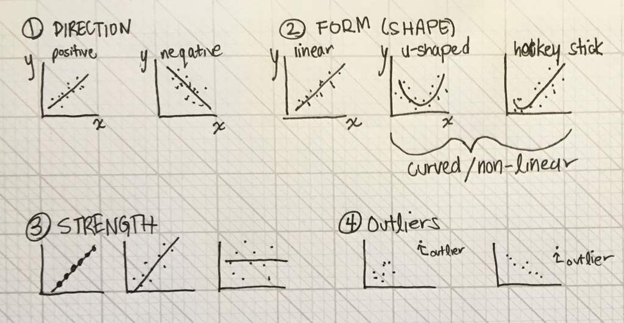

# Bi-directional relationships ex: systolic and diastolic BP

Read in NHANES dataset

```r
library(readr)
nhanes <- read_csv("./data/BPXI_I.csv")
```

```
## ──────────────────────────────────────────────────────── Delimiter: "," dbl
## (22): ...1, SEQN, PEASCCT1, BPXCHR, BPAARM, BPACSZ, BPXPLS, BPXPULS, BPX...
```

```r
head(nhanes)
```

```
## # A tibble: 6 × 22
##    ...1  SEQN PEASCCT1 BPXCHR BPAARM BPACSZ BPXPLS BPXPULS BPXPTY BPXML1 BPXSY1
##   <dbl> <dbl>    <dbl>  <dbl>  <dbl>  <dbl>  <dbl>   <dbl>  <dbl>  <dbl>  <dbl>
## 1     1 83732       NA     NA      1      4     76       1      1    150    128
## 2     2 83733       NA     NA      1      4     72       1      1    170    146
## 3     3 83734       NA     NA      1      4     56       1      1    160    138
## 4     4 83735       NA     NA      1      5     78       1      1    150    132
## 5     5 83736       NA     NA      1      3     76       1      1    130    100
## 6     6 83737       NA     NA      1      4     64       1      1    140    116
## # ℹ 11 more variables: BPXDI1 <dbl>, BPAEN1 <dbl>, BPXSY2 <dbl>, BPXDI2 <dbl>,
## #   BPAEN2 <dbl>, BPXSY3 <dbl>, BPXDI3 <dbl>, BPAEN3 <dbl>, BPXSY4 <dbl>,
## #   BPXDI4 <dbl>, BPAEN4 <dbl>
```

```r
# View(nhanes) #Viewer provides data labels which are very useful for picking which variables to plot
```

# Bi-directional relationships ex: systolic and diastolic BP

```r
library(ggplot2)
bp_plot <- ggplot(nhanes, aes(x = BPXSY1, y = BPXDI1)) +
  geom_point(alpha = 0.1) +
  theme_minimal(base_size = 15) +
  labs(x = "Systolic BP, mm Hg",
       y = "Diastolic BP, mm Hg",
       title = "NHANES Data")
```

# Bi-directional relationships ex: systolic and diastolic BP

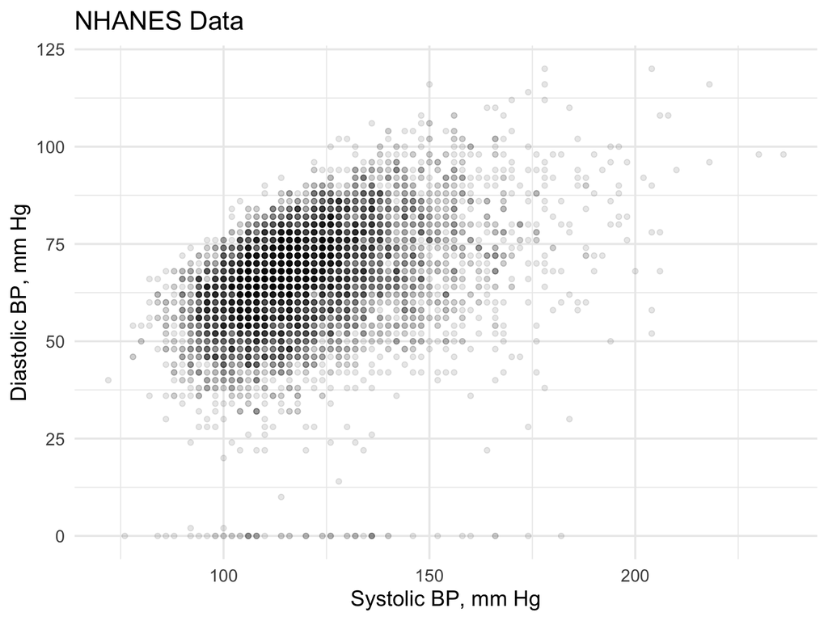

# Bi-directional relationships ex: systolic and diastolic BP

What do we notice from the plot?

- **Direction**: Positive or negative?
- **Form**: Linear or curved?
- **Strength**: How close do the points lie to a line?
- **Outliers**: Any individuals outside the general pattern?

# Association with a plausible direction: motor boats and manatees

Read in the manatee data set (from the text book):

```r
library(readr)
mana_data <- read_csv("./data/Ch03_Manatee-deaths.csv")
```

# Association with a plausible direction: motor boats and manatees

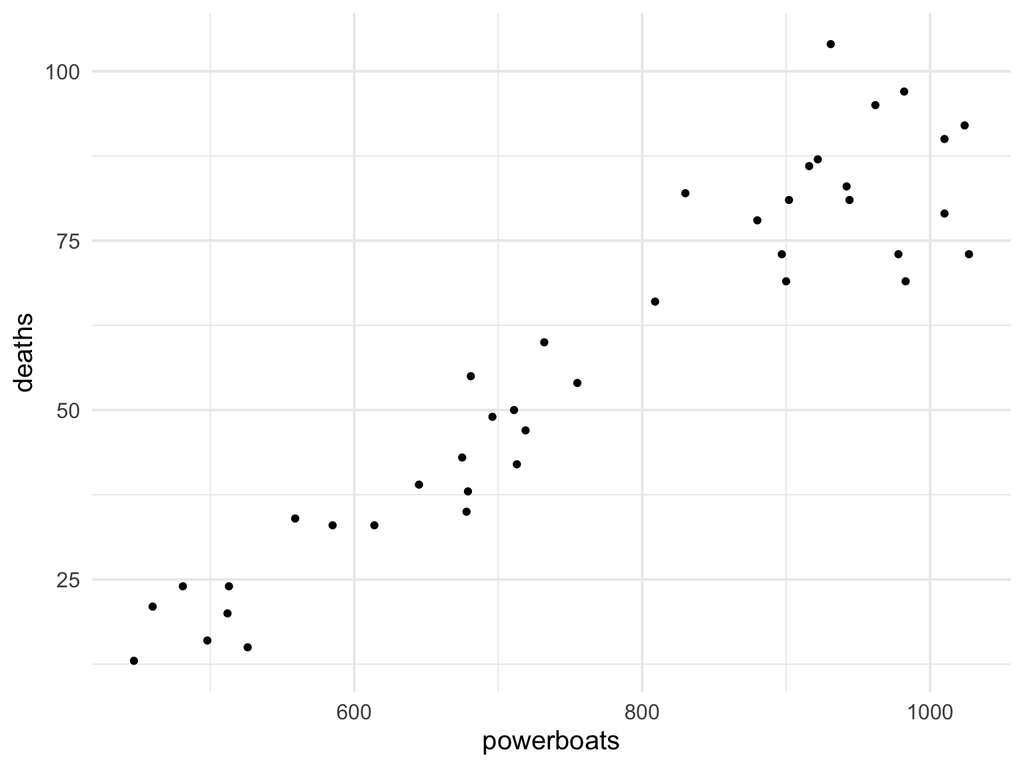

```r
mana_scatter <- ggplot(data = mana_data, aes(x = powerboats, y = deaths)) +
  geom_point() +
  theme_minimal(base_size = 15)

mana_scatter
```

# Association with a plausible direction: motor boats and manatees

What do we notice from the plot?

- **Direction**: Positive or negative?
- **Form**: Linear or curved?
- **Strength**: How close do the points lie to a line?
- **Outliers**: Any individuals outside the general pattern?

# Exercise: Power boats and Manatees

- Add (in thousands) to the x-axis title
- Change the point colour
- Is there a way to incorporate information on year into the graph?

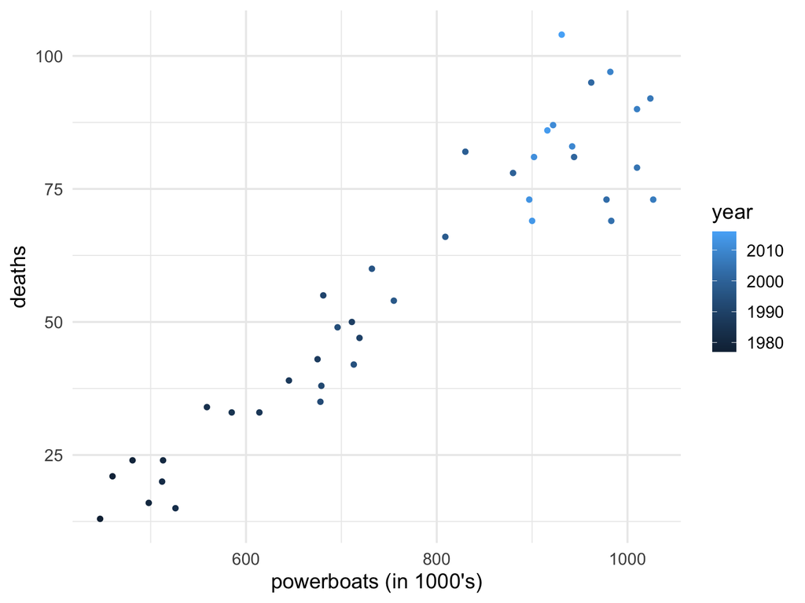

```r
ggplot(data = mana_data, aes(x = powerboats, y = deaths)) +
  geom_point(aes(col=year)) +
  theme_minimal(base_size = 15)+labs(x="powerboats (in 1000's)")
```

# Example 3: Enzyme activity and temperature

- A study examined the activity rate (in micromoles per second) of a digestive enzyme at varying temperatures.

```r
# this dataset was provided in Baldi and Moore Ed#4 Apply your knowledge 3.4
enzyme_data <- read_csv("./data/Ch03_Enzyme-data.csv")
head(enzyme_data)
```

```
## # A tibble: 6 × 2
##   temperature  rate
##         <dbl> <dbl>
## 1         298  0.04
## 2         298  0.05
## 3         298  0.05
## 4         303  0.08
## 5         303  0.08
## 6         303  0.08
```

# Scatter plot for enzyme data

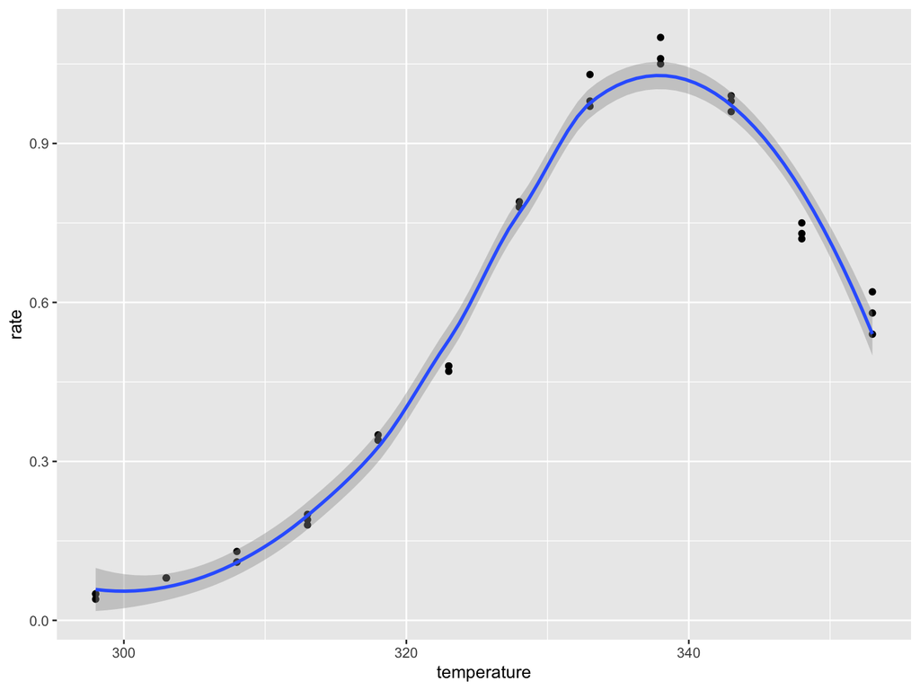

```r
ggplot(enzyme_data, aes(x = temperature, y = rate)) +
  geom_point() +
  geom_smooth()
```

Direction:

Form:

Strength:

Outliers:

# Example 4: Gestational age and perinatal mortality

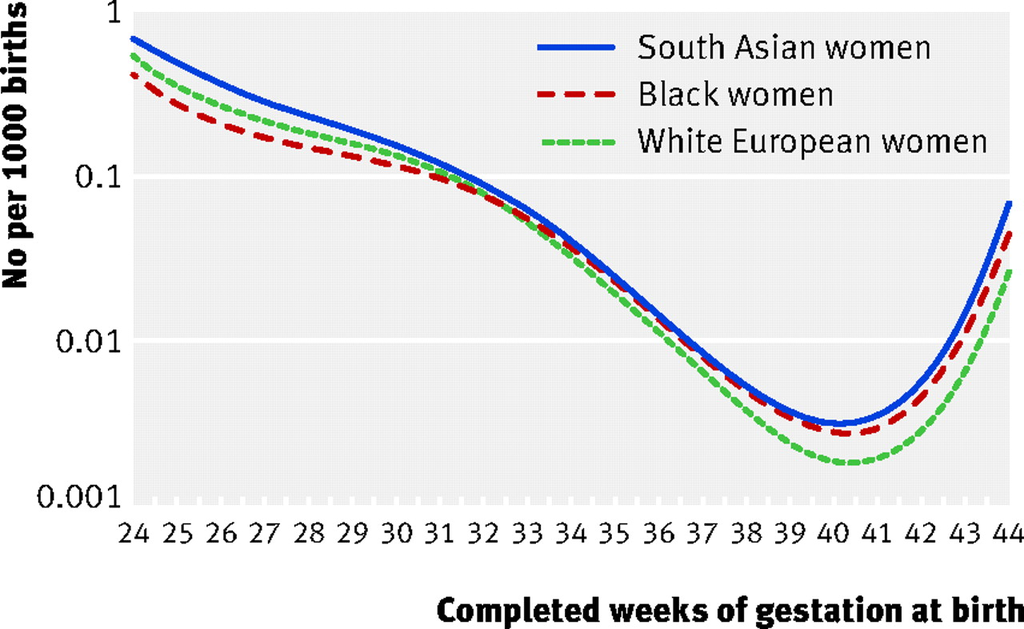

Source: [Balchin et al. BMJ. 2007.](https://www.bmj.com/content/334/7598/833)

# Example 5: Lean body mass and metabolic rate

Problem: Is lean body mass (person’s weight after removing the fat) associated with metabolic rate (kilocalories burned in 24 hours)?

Plan: A diet study was conducted on 12 women and 7 men that measured lean body weight and metabolic rate for each individual.

# Lean body mass and metabolic rate

Data:

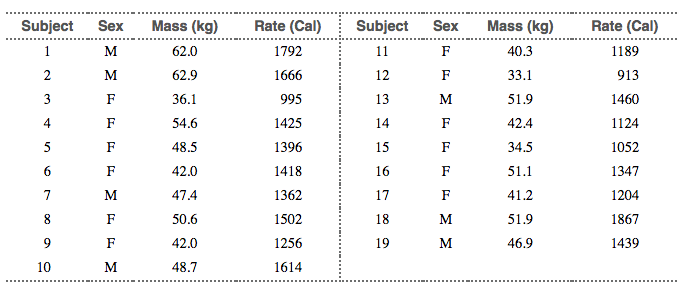

- What would the corresponding data frame look like in R?
- How many variables does it have?
- How many rows?

# Lean body mass and metabolic rate

```r
# Note: you won't be tested on writing code using tibble::tribble()
# **Do** know how to look at this code and recognize that it is creating a data set

weight_data <- tibble::tribble(
  ~subject, ~gender, ~mass, ~rate,
  1, "M", 62.0, 1792,
  2, "M", 62.9, 1666,
  3, "F", 36.1, 995,
  4, "F", 54.6, 1425,
  5, "F", 48.5, 1396,
  6, "F", 42.0, 1418,
  7, "M", 47.4, 1362,
  8, "F", 50.6, 1502,
  9, "F", 42.0, 1256,
  10, "M", 48.7, 1614,
  11, "F", 40.3, 1189,
  12, "F", 33.1, 913,
  13, "M", 51.9, 1460,
  14, "F", 42.4, 1124,
  15, "F", 34.5, 1052,
  16, "F", 51.1, 1347,
  17, "F", 41.2, 1204,
  18, "M", 51.9, 1867,
  19, "M", 46.9, 1439
)
```

# Analysis

Exploratory data analysis using scatter plots

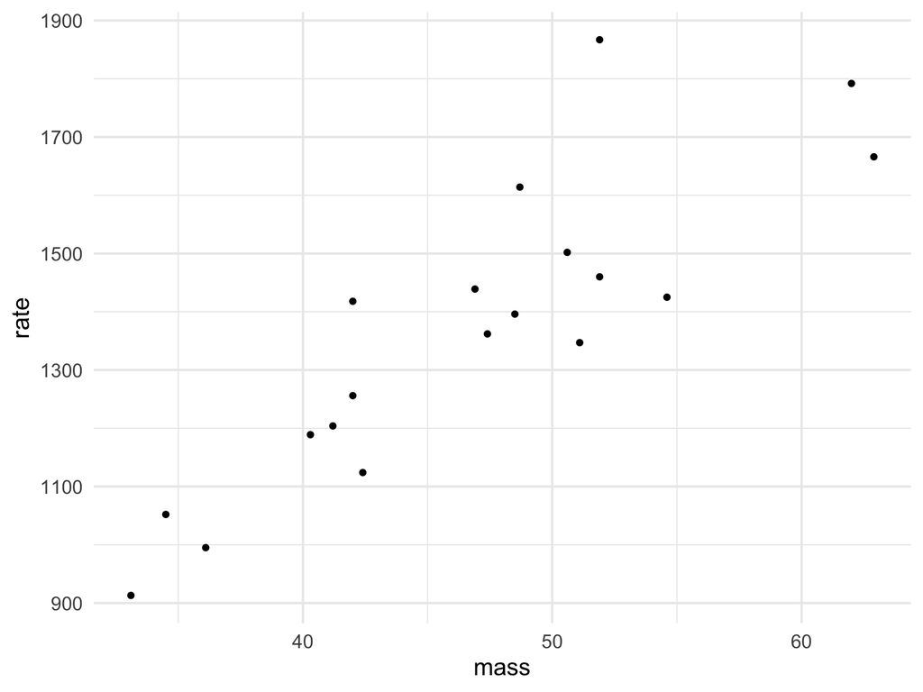

```r
weight_scatter <- ggplot(weight_data, aes(x = mass, y = rate)) +
  geom_point() +
  theme_minimal(base_size = 15)

weight_scatter
```

# Analysis: Colour the points by gender

```r
#Fill in during class
```

# Analysis: Create separate plots for men and women

```r
#Fill in during class
```

# Conclusion

Direction:

Form:

Strength:

Outliers:

# Pearson’s correlation

Using just our eyes, we can often say something about whether an association between two variables is weak or strong.

```
Attaching package: 'patchwork'
```

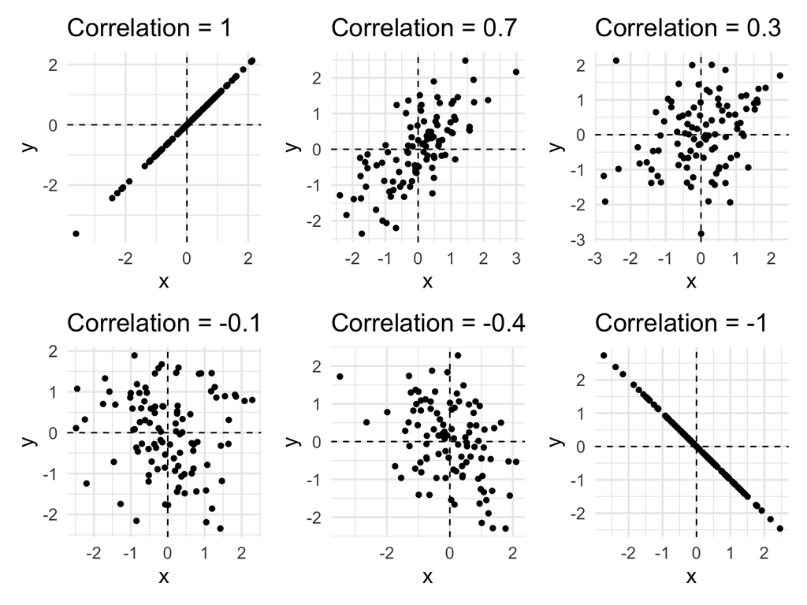

# Pearson’s correlation

- For **linear** associations, we can use **Pearson’s correlation coefficient** (denoted by $r$) to **quantify the strength** of a linear relationship between two variables.
- The correlation between $x$ and $y$ is:

$$r=\frac{1}{n-1}\sum_{i=1}^n(\frac{x_i-\bar{x}}{s_x})(\frac{y_i-\bar{y}}{s_y})$$

# Intuition about Pearson’s correlation

To understand this formula, first only consider the numerators of the fractions (i.e., $x_i-\bar{x}$ and $y_i-\bar{y}$). If you imagine a scatter plot of x and y, we can also add a dashed line at the mean x value of $\bar{x}$ and a dashed line line at the mean y value ($\bar{y}$):

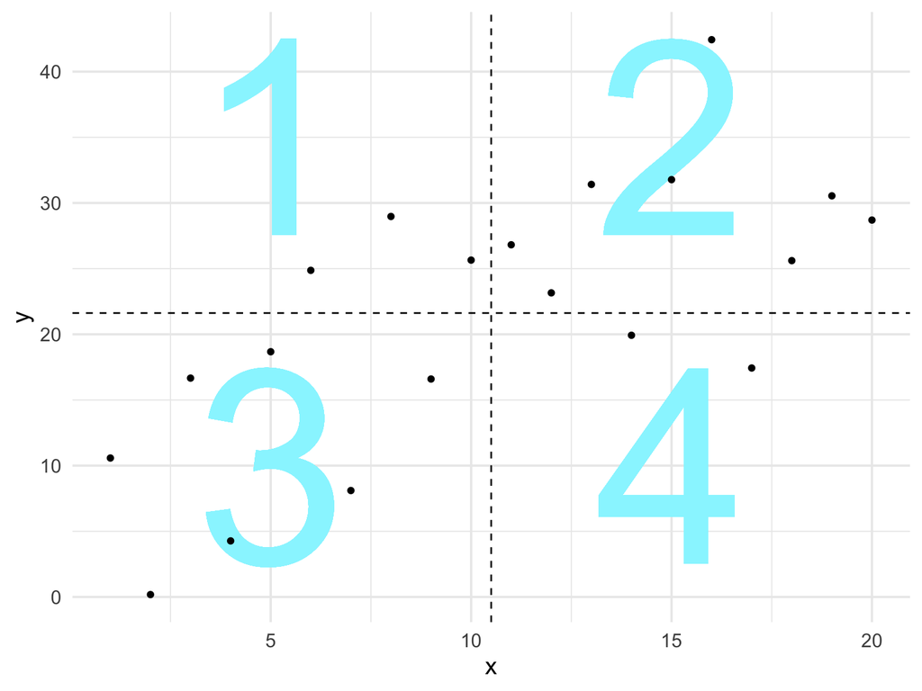

# Intuition about Pearson’s correlation

$r=\frac{1}{n-1}\sum_{i=1}^n(\frac{x_i-\bar{x}}{s_x})(\frac{y_i-\bar{y}}{s_y})$

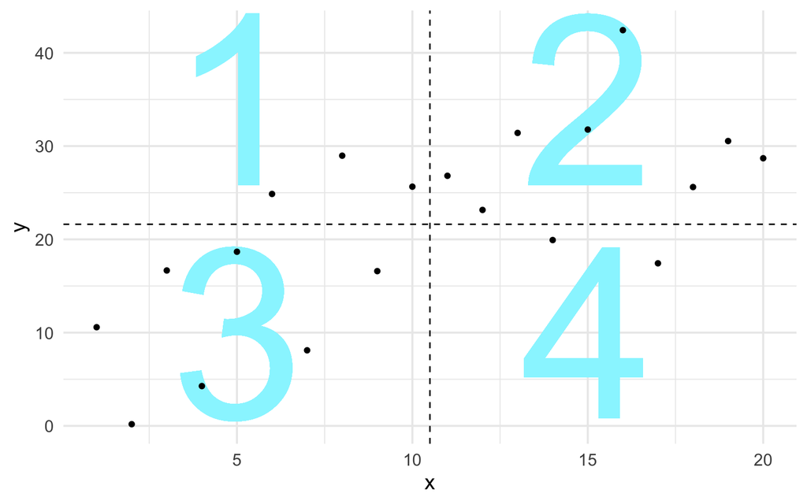

- Points in Q2 and Q3 contribute positive products to $r$
- Points in Q1 and Q4 contribute negative products to $r$
- The more there are points in Q2 and Q3 vs. Q1 and Q4, the more the value of the correlation coefficient will be higher and positive
- If you want even more of an explanation see the response to this [stack overflow post](https://stats.stackexchange.com/questions/18058/how-would-you-explain-covariance-to-someone-who-understands-only-the-mean/18200#18200) or take an intermediate statistics class!

# Syntax: Pearson’s correlation using `cor()`

```r
# Students, if you copy this code chunk, you need to set eval = T in the code chunk header for the code to compile

correlation_coeff <- dataset %>%
  summarize(new_var = cor(x_variable, y_variable))
```

# Syntax: Pearson’s correlation using `cor()`

Remember the manatee plot and the weight plot:

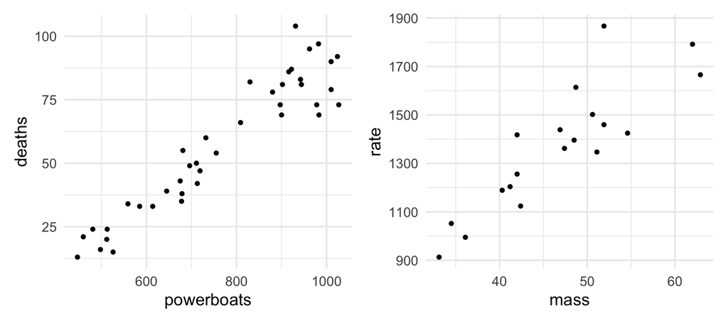

# Syntax: Pearson’s correlation using `cor()`

Now, calculate the correlations between X and Y for manatees:

```r
library(dplyr)
mana_cor <- mana_data %>%
  summarize(corr_mana = cor(powerboats, deaths))

mana_cor
```

```
## # A tibble: 1 × 1
##   corr_mana
##       <dbl>
## 1     0.945
```

# Syntax: Pearson’s correlation using `cor()`

And for the weight data:

```r
weight_cor <- weight_data %>%
  summarize(corr_weight = cor(mass, rate))
weight_cor
```

```
## # A tibble: 1 × 1
##   corr_weight
##         <dbl>
## 1       0.865
```

# Properties of the correlation coefficient

- Always a number between -1 and 1.
  - -1: A perfect, negative linear association
  - 1: A perfect, positive linear association
  - 0: No linear association
- Measures association *not* causation. Even a very strong association doesn’t mean that one variable causes the other.
- Is used to measure the association between two *quantitative* variables.
- Only useful for *linear* associations!

# Properties of the correlation coefficient

- The correlation coefficient is not resistant to outliers
- E.g., I added two outliers (in red) to the weight_data and recalculated correlation. How much did the correlation change? (It is labelled on each plot.)

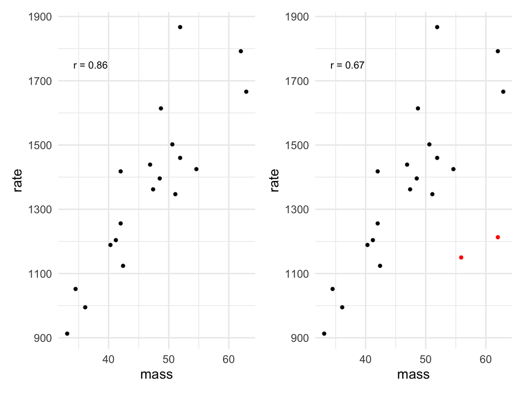

# Properties of the correlation coefficient

- Correlations for average measures is typically stronger than correlations for individual data

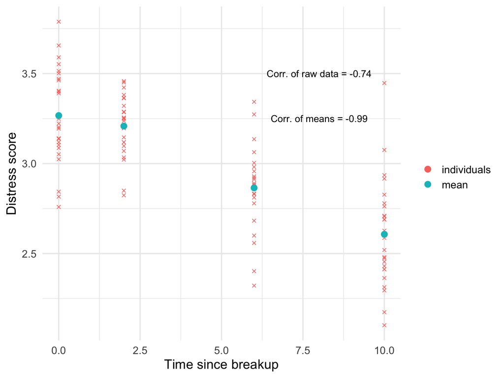

# Recap: What functions did we use?

# Important concepts

- Determine which variable is explanatory and which is response, or when it doesn’t matter
- Describe the relationship between two variables (form, direction, strength, and outliers)
- Formula for and properties of the correlation coefficient $r$